# Analysis

- Jordan Maulino jpmaulino@dons.usfca.edu
- Chezka Sino msino@dons.usfca.edu
- Bob Horton cybertory@gmail.com or rhorton@microsoft.com

## Introduction

Given this dataset, we were asked to explore the correlations between a diabetic patient’s probability of being readmitted within the first thirty days and the various features included.

## Loading the patient data

```r
set.seed(1)
patients <- read.csv("sim_data.csv")
patients$X <- NULL


summary(patients)
```

```
##  readmitted  readmit30            bmi        pct_calories_from_carbs
##  <30: 5199   Mode :logical   Min.   : 0.16   Min.   :21.86
##  >30:17861   FALSE:45265     1st Qu.:21.28   1st Qu.:45.32
##  NO :27404   TRUE :5199      Median :25.26   Median :50.44
##              NA's :0         Mean   :25.45   Mean   :50.56
##                              3rd Qu.:29.35   3rd Qu.:55.66
##                              Max.   :46.50   Max.   :82.78
##  minutes_walking   sd_glucose    irs1
##  Min.   :  9.0   Min.   :0.000   GG:42931
##  1st Qu.:107.0   1st Qu.:2.259   GR: 4782
##  Median :153.0   Median :2.794   RR: 2751
##  Mean   :157.5   Mean   :2.918
##  3rd Qu.:204.0   3rd Qu.:3.465
##  Max.   :411.0   Max.   :7.548
```

First, let’s take a look a plots of each variable and plot them against our response, readmit30, to see if there are any notable trends.

## Visualizing the data

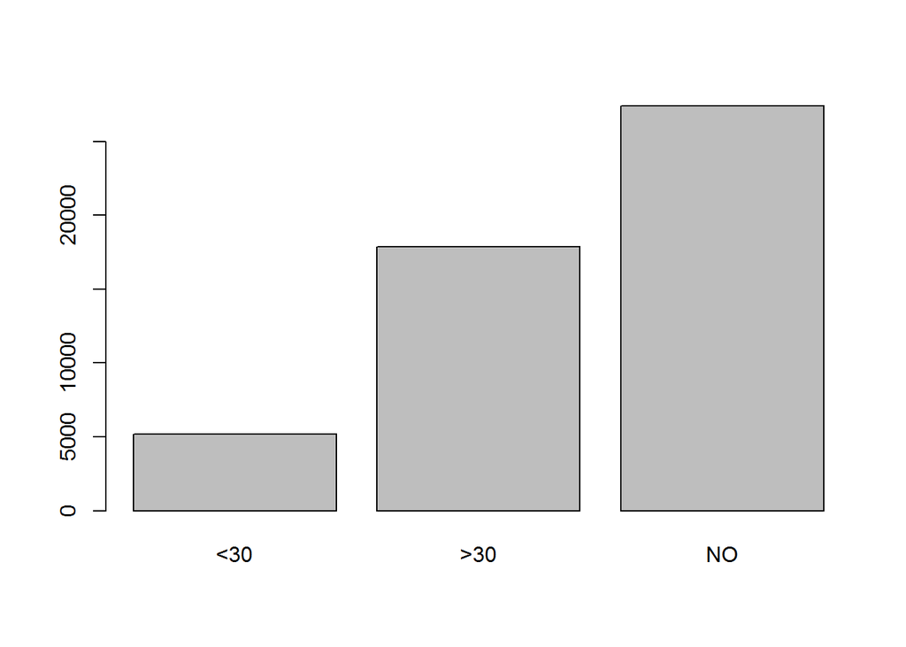

```r
plot(patients$readmitted)
```

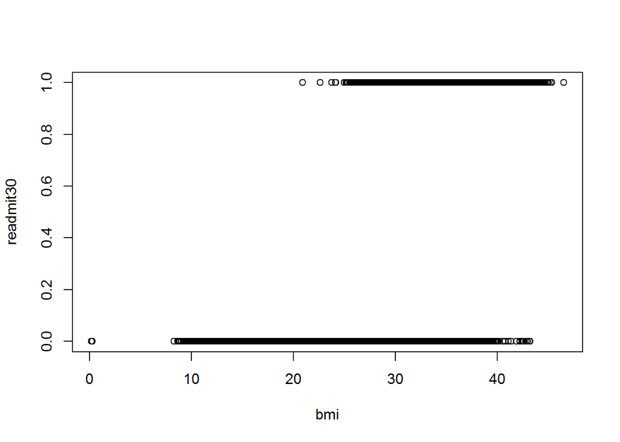

```r
with(patients, plot(readmit30 ~ bmi))
```

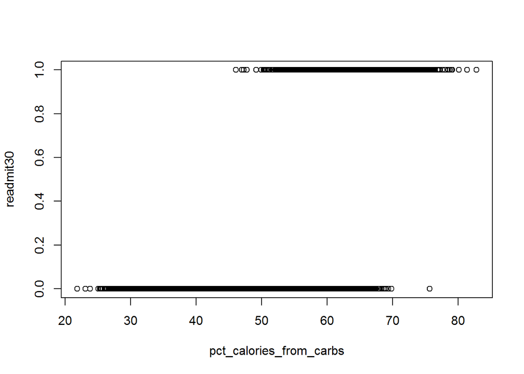

```r
with(patients, plot(readmit30 ~ pct_calories_from_carbs))
```

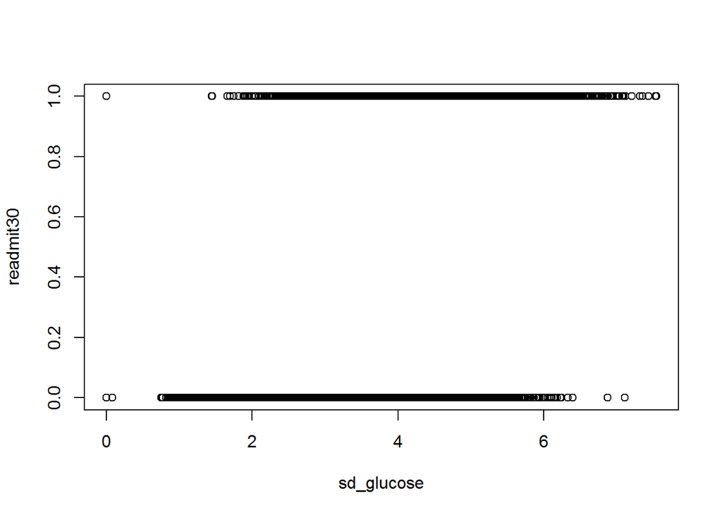

```r
with(patients, plot(readmit30 ~ sd_glucose))
```

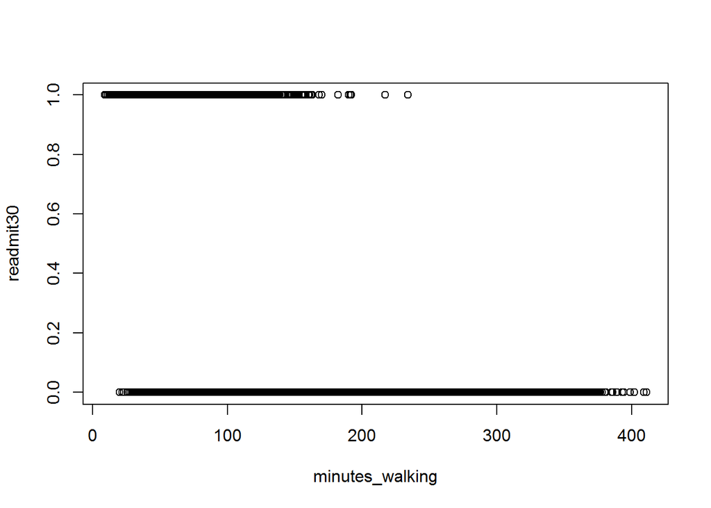

```r
with(patients, plot(readmit30 ~ minutes_walking))
```

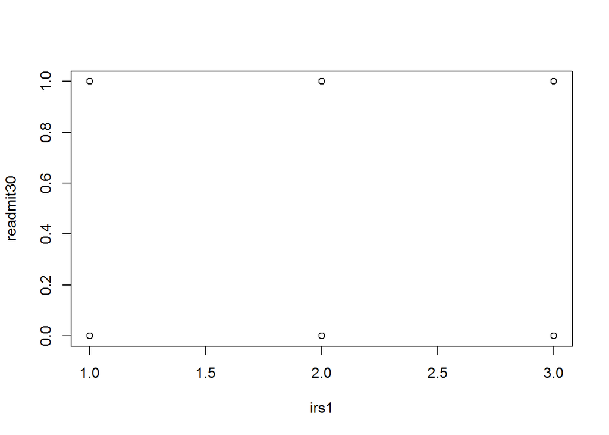

```r
with(patients, plot(readmit30 ~ irs1))
```

At a glance it is hard to come to any conclusions regarding these features’ effects on a patient’s probability of being readmitted. Let’s try fitting the data to a model.

## Model Fitting

First, we fit a model to see which features have a significant effect on the patients readmittance. Below is the full model.

```r
model <- glm(readmit30 ~ bmi + pct_calories_from_carbs + minutes_walking + sd_glucose + irs1, patients, family=binomial(link="logit"))
summary(model)
```

```
##
## Call:
## glm(formula = readmit30 ~ bmi + pct_calories_from_carbs + minutes_walking +
##     sd_glucose + irs1, family = binomial(link = "logit"), data = patients)
##
## Deviance Residuals:
##     Min       1Q   Median       3Q      Max
## -3.6458  -0.0131  -0.0006   0.0000   4.2710
##
## Coefficients:
##                           Estimate Std. Error z value Pr(>|z|)
## (Intercept)             -31.561223   1.221225  -25.84   <2e-16 ***
## bmi                       0.534114   0.015392   34.70   <2e-16 ***
## pct_calories_from_carbs   0.219612   0.018621   11.79   <2e-16 ***
## minutes_walking          -0.055099   0.001678  -32.84   <2e-16 ***
## sd_glucose                1.072624   0.046475   23.08   <2e-16 ***
## irs1GR                    3.442293   0.189642   18.15   <2e-16 ***
## irs1RR                    1.625508   0.138784   11.71   <2e-16 ***
## ---
## Signif. codes:  0 '***' 0.001 '**' 0.01 '*' 0.05 '.' 0.1 ' ' 1
##
## (Dispersion parameter for binomial family taken to be 1)
##
##     Null deviance: 33475.5  on 50463  degrees of freedom
## Residual deviance:  3434.2  on 50457  degrees of freedom
## AIC: 3448.2
##
## Number of Fisher Scoring iterations: 10
```

```r
coef(model)
```

```
##             (Intercept)                     bmi pct_calories_from_carbs
##            -31.56122296              0.53411427              0.21961168
##         minutes_walking              sd_glucose                  irs1GR
##             -0.05509879              1.07262394              3.44229258
##                  irs1RR
##              1.62550767
```

All of these features seem to have a significant effect on a patient’s readmittance. However, we were skeptical about the relationship between a patient’s BMI and their percent of calories from carbs — as this could cause multicollinearity.

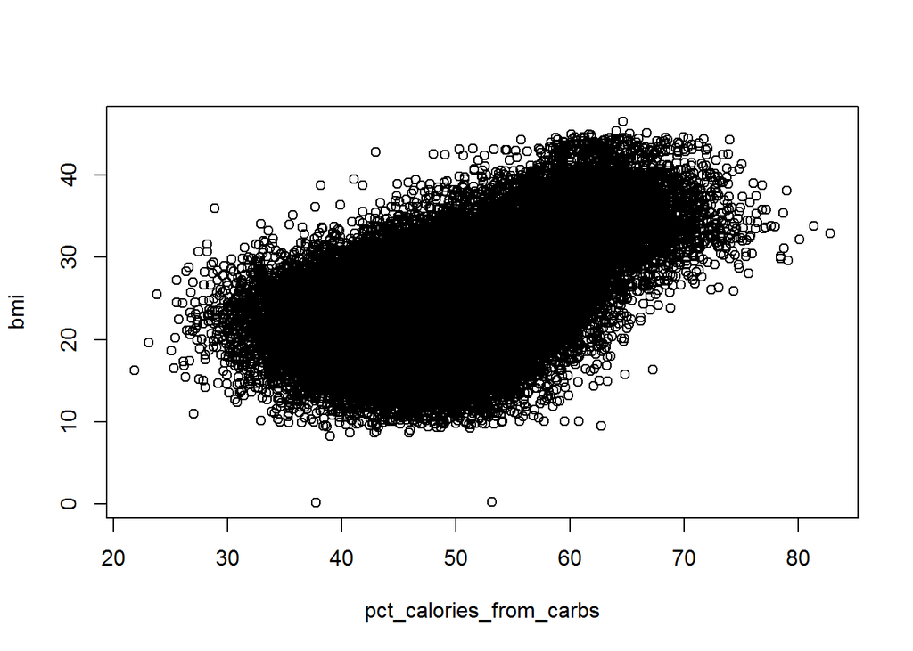

```r
with(patients, plot(bmi ~ pct_calories_from_carbs))
```

```r
cor(patients$bmi, patients$pct_calories_from_carbs)
```

```
## [1] 0.5493947
```

Plotting these two variables against each other displays what looks like a positive correlation between a patient’s BMI and their percent calories from carbohydrates consumed. Although there only seems to be a moderate correlation of approximately .55 between these two variables, let’s try reducing the model to only include a patient’s percent calories from carbs. Because a patient’s BMI is based only off of their height/weight, this may not be always be the best predictor in regard to their readmission. For example, a tall patient may have a very high BMI, but be healthy nonetheless.

```r
model2 <- glm(readmit30 ~ pct_calories_from_carbs + minutes_walking + sd_glucose + irs1, patients, family=binomial(link="logit"))
summary(model2)
```

```
##
## Call:
## glm(formula = readmit30 ~ pct_calories_from_carbs + minutes_walking +
##     sd_glucose + irs1, family = binomial(link = "logit"), data = patients)
##
## Deviance Residuals:
##     Min       1Q   Median       3Q      Max
## -3.2970  -0.0469  -0.0064  -0.0009   4.1542
##
## Coefficients:
##                           Estimate Std. Error z value Pr(>|z|)
## (Intercept)             -13.973320   0.807784  -17.30   <2e-16 ***
## pct_calories_from_carbs   0.207463   0.014324   14.48   <2e-16 ***
## minutes_walking          -0.055469   0.001311  -42.31   <2e-16 ***
## sd_glucose                1.100019   0.037135   29.62   <2e-16 ***
## irs1GR                    3.405511   0.144572   23.56   <2e-16 ***
## irs1RR                    1.535696   0.105588   14.54   <2e-16 ***
## ---
## Signif. codes:  0 '***' 0.001 '**' 0.01 '*' 0.05 '.' 0.1 ' ' 1
##
## (Dispersion parameter for binomial family taken to be 1)
##
##     Null deviance: 33475.5  on 50463  degrees of freedom
## Residual deviance:  5840.5  on 50458  degrees of freedom
## AIC: 5852.5
##
## Number of Fisher Scoring iterations: 9
```

```r
coef(model2)
```

```
##             (Intercept) pct_calories_from_carbs         minutes_walking
##            -13.97331967              0.20746287             -0.05546859
##              sd_glucose                  irs1GR                  irs1RR
##              1.10001911              3.40551057              1.53569623
```

Removing BMI from our model results in a higher AIC value than before, implying that the full model fits the data better.

It is interesting that the IRS1 gene is included in this dataset. Perhaps certain alleles of this gene have an effect on the probability of being readmitted when interacting with some of the other features. Let’s try another model which includes the interactions between the IRS1 gene and the other predictor variables.

## Interactions with the IRS1 gene

```r
model3 <- glm(readmit30 ~ irs1 * (pct_calories_from_carbs + sd_glucose + minutes_walking + bmi), patients, family = binomial(link="logit"))
summary(model3)
```

```
##
## Call:
## glm(formula = readmit30 ~ irs1 * (pct_calories_from_carbs + sd_glucose +
##     minutes_walking + bmi), family = binomial(link = "logit"),
##     data = patients)
##
## Deviance Residuals:
##     Min       1Q   Median       3Q      Max
## -3.6158  -0.0109  -0.0004   0.0000   4.4688
##
## Coefficients:
##                                  Estimate Std. Error z value Pr(>|z|)
## (Intercept)                    -33.787875   1.887187 -17.904  < 2e-16 ***
## irs1GR                           0.734116   2.958161   0.248  0.80401
## irs1RR                          37.960662   4.458518   8.514  < 2e-16 ***
## pct_calories_from_carbs          0.262145   0.027672   9.473  < 2e-16 ***
## sd_glucose                       1.264137   0.091085  13.879  < 2e-16 ***
## minutes_walking                 -0.059267   0.003153 -18.795  < 2e-16 ***
## bmi                              0.517459   0.024865  20.811  < 2e-16 ***
## irs1GR:pct_calories_from_carbs   0.021996   0.041917   0.525  0.59975
## irs1RR:pct_calories_from_carbs  -0.605379   0.072458  -8.355  < 2e-16 ***
## irs1GR:sd_glucose               -0.388612   0.114109  -3.406  0.00066 ***
## irs1RR:sd_glucose               -0.044864   0.135251  -0.332  0.74011
## irs1GR:minutes_walking           0.008708   0.004035   2.158  0.03090 *
## irs1RR:minutes_walking           0.001083   0.004693   0.231  0.81755
## irs1GR:bmi                       0.052482   0.037249   1.409  0.15885
## irs1RR:bmi                      -0.015863   0.038736  -0.410  0.68217
## ---
## Signif. codes:  0 '***' 0.001 '**' 0.01 '*' 0.05 '.' 0.1 ' ' 1
##
## (Dispersion parameter for binomial family taken to be 1)
##
##     Null deviance: 33475.5  on 50463  degrees of freedom
## Residual deviance:  3320.4  on 50449  degrees of freedom
## AIC: 3350.4
##
## Number of Fisher Scoring iterations: 11
```

This model produces some interesting results. Notably, we see a significant negative coefficient for the interaction between the IRS1 RR allele and the percent of calories from carbohydrates a patient consumes. We also see a significant negative coefficient between the GR allele and a patient’s standard deviation in glucose levels.

By taking a look at the summary of the data above, we see that the RR allele appears in only 2,751 patients in the data set (only 5.4%). Interestingly, the percentage of calories from carbs in a patient’s diet has a positive effect (a .26 coefficient) on whether or not a patient is readmitted within the first 30 days. However, when looking at the interaction between the RR allele and this percentage, we get a **significant negative** coefficient (-.61). Perhaps diabetic patients with the RR IRS1 allele consume a higher percentage of calories from carbohydrates, yet, have a lower chance of being readmitted. However, this is an unusual assumption…

Let’s try subsetting the data by genotype to see what kind of effects each allele has on a patient’s readmittance.

## Subsetting the Data by Genotype

```r
patients_RR <- patients[patients$irs1 == "RR", ]
patients_GR <- patients[patients$irs1 == "GR", ]
patients_GG <- patients[patients$irs1 == "GG", ]

summary(patients_RR)
```

```
##  readmitted readmit30            bmi        pct_calories_from_carbs
##  <30: 788   Mode :logical   Min.   :13.21   Min.   :54.85
##  >30:1922   FALSE:1963      1st Qu.:26.54   1st Qu.:58.50
##  NO :  41   TRUE :788       Median :29.85   Median :59.41
##             NA's :0         Mean   :30.00   Mean   :59.41
##                             3rd Qu.:33.29   3rd Qu.:60.36
##                             Max.   :44.52   Max.   :64.46
##  minutes_walking   sd_glucose    irs1
##  Min.   : 10.0   Min.   :0.000   GG:   0
##  1st Qu.: 71.0   1st Qu.:2.897   GR:   0
##  Median :103.0   Median :3.469   RR:2751
##  Mean   :107.5   Mean   :3.568
##  3rd Qu.:138.0   3rd Qu.:4.140
##  Max.   :308.0   Max.   :7.435
```

```r
summary(patients_GR)
```

```
##  readmitted readmit30            bmi        pct_calories_from_carbs
##  <30:3994   Mode :logical   Min.   : 9.53   Min.   :56.94
##  >30: 782   FALSE:788       1st Qu.:31.39   1st Qu.:61.82
##  NO :   6   TRUE :3994      Median :33.96   Median :63.57
##             NA's :0         Mean   :33.94   Mean   :64.25
##                             3rd Qu.:36.89   3rd Qu.:66.00
##                             Max.   :46.50   Max.   :82.78
##  minutes_walking    sd_glucose    irs1
##  Min.   :  9.00   Min.   :0.000   GG:   0
##  1st Qu.: 46.00   1st Qu.:3.469   GR:4782
##  Median : 65.00   Median :4.127   RR:   0
##  Mean   : 73.88   Mean   :4.094
##  3rd Qu.: 92.00   3rd Qu.:4.775
##  Max.   :322.00   Max.   :7.548
```

```r
summary(patients_GG)
```

```
##  readmitted  readmit30            bmi        pct_calories_from_carbs
##  <30:  417   Mode :logical   Min.   : 0.16   Min.   :21.86
##  >30:15157   FALSE:42514     1st Qu.:20.61   1st Qu.:44.38
##  NO :27357   TRUE :417       Median :24.30   Median :49.00
##              NA's :0         Mean   :24.21   Mean   :48.47
##                              3rd Qu.:27.81   3rd Qu.:53.18
##                              Max.   :44.30   Max.   :62.47
##  minutes_walking   sd_glucose    irs1
##  Min.   : 11     Min.   :0.000   GG:42931
##  1st Qu.:123     1st Qu.:2.184   GR:    0
##  Median :165     Median :2.667   RR:    0
##  Mean   :170     Mean   :2.745
##  3rd Qu.:213     3rd Qu.:3.237
##  Max.   :411     Max.   :7.114
```

Now that we have subset the data, let’s fit them to linear models and see how their results compare to results from our initial interaction model.

## Fitting the Subsets

```r
model.RR <- glm(readmit30 ~ bmi + pct_calories_from_carbs + minutes_walking + sd_glucose, patients_RR, family=binomial(link="logit"))
summary(model.RR)
```

```
##
## Call:
## glm(formula = readmit30 ~ bmi + pct_calories_from_carbs + minutes_walking +
##     sd_glucose, family = binomial(link = "logit"), data = patients_RR)
##
## Deviance Residuals:
##     Min       1Q   Median       3Q      Max
## -3.3242  -0.1788  -0.0401   0.0588   3.5636
##
## Coefficients:
##                          Estimate Std. Error z value Pr(>|z|)
## (Intercept)              4.172787   4.039115   1.033    0.302
## bmi                      0.501596   0.029698  16.890  < 2e-16 ***
## pct_calories_from_carbs -0.343234   0.066960  -5.126 2.96e-07 ***
## minutes_walking         -0.058185   0.003475 -16.742  < 2e-16 ***
## sd_glucose               1.219273   0.099973  12.196  < 2e-16 ***
## ---
## Signif. codes:  0 '***' 0.001 '**' 0.01 '*' 0.05 '.' 0.1 ' ' 1
##
## (Dispersion parameter for binomial family taken to be 1)
##
##     Null deviance: 3295.34  on 2750  degrees of freedom
## Residual deviance:  866.87  on 2746  degrees of freedom
## AIC: 876.87
##
## Number of Fisher Scoring iterations: 7
```

```r
model.GR <- glm(readmit30 ~ bmi + pct_calories_from_carbs + minutes_walking + sd_glucose, patients_GR, family=binomial(link="logit"))
summary(model.GR)
```

```
##
## Call:
## glm(formula = readmit30 ~ bmi + pct_calories_from_carbs + minutes_walking +
##     sd_glucose, family = binomial(link = "logit"), data = patients_GR)
##
## Deviance Residuals:
##     Min       1Q   Median       3Q      Max
## -3.6158   0.0120   0.0547   0.1574   2.7666
##
## Coefficients:
##                           Estimate Std. Error z value Pr(>|z|)
## (Intercept)             -33.053759   2.277990 -14.510   <2e-16 ***
## bmi                       0.569942   0.027736  20.549   <2e-16 ***
## pct_calories_from_carbs   0.284141   0.031485   9.025   <2e-16 ***
## minutes_walking          -0.050559   0.002517 -20.086   <2e-16 ***
## sd_glucose                0.875525   0.068734  12.738   <2e-16 ***
## ---
## Signif. codes:  0 '***' 0.001 '**' 0.01 '*' 0.05 '.' 0.1 ' ' 1
##
## (Dispersion parameter for binomial family taken to be 1)
##
##     Null deviance: 4280.1  on 4781  degrees of freedom
## Residual deviance: 1184.7  on 4777  degrees of freedom
## AIC: 1194.7
##
## Number of Fisher Scoring iterations: 8
```

```r
model.GG <- glm(readmit30 ~ bmi + pct_calories_from_carbs + minutes_walking + sd_glucose, patients_GG, family=binomial(link="logit"))
summary(model.GG)
```

```
##
## Call:
## glm(formula = readmit30 ~ bmi + pct_calories_from_carbs + minutes_walking +
##     sd_glucose, family = binomial(link = "logit"), data = patients_GG)
##
## Deviance Residuals:
##     Min       1Q   Median       3Q      Max
## -2.4660  -0.0090  -0.0005  -0.0001   4.4688
##
## Coefficients:
##                           Estimate Std. Error z value Pr(>|z|)
## (Intercept)             -33.787875   1.887187 -17.904   <2e-16 ***
## bmi                       0.517459   0.024865  20.811   <2e-16 ***
## pct_calories_from_carbs   0.262145   0.027672   9.473   <2e-16 ***
## minutes_walking          -0.059267   0.003153 -18.795   <2e-16 ***
## sd_glucose                1.264137   0.091085  13.879   <2e-16 ***
## ---
## Signif. codes:  0 '***' 0.001 '**' 0.01 '*' 0.05 '.' 0.1 ' ' 1
##
## (Dispersion parameter for binomial family taken to be 1)
##
##     Null deviance: 4694.9  on 42930  degrees of freedom
## Residual deviance: 1268.8  on 42926  degrees of freedom
## AIC: 1278.8
##
## Number of Fisher Scoring iterations: 11
```

After fitting the subsets to logistic regression models, we see that the model that was fit to the RR subset fit the data the best, producing the lowest AIC. What is most striking about this model is that it is the only model of the three subsets which produces a **negative** coefficient for the percent calories from carbs in a patient’s diet. This unusual, yet striking, result affirms our earlier assumption regarding the RR allele.

Let’s look at the differences in probabilities of being readmitted within the first 30 days among the three genotypes. To do so, let’s create a dataframe with two rows of patient data — one row will contain 40% calories from carbohydrates and the other will contain 60%. Because we are only interested in the interaction between the patient’s IRS1 genotype and their percent calories from carbs consumed, all other features will remain constant, using the median values from the RR subset.

We will use this new data frame to predict a patient’s probability of being readmitted within 30 days for each value of % calories from carbs and repeat this process for each genotype.

```r
newdata = data.frame(pct_calories_from_carbs = c(40,60), bmi = c(29.85,29.85), minutes_walking = c(103.0,103.0), sd_glucose = c(3.469,3.469), irs1 = c("GG", "GG"))

p <- predict(model3, newdata, type = "response", interval = "confidence")
p
```

```
##            1            2
## 0.0000694272 0.0129673508
```

```r
newdata2 = data.frame(pct_calories_from_carbs = c(40,60), bmi = c(29.85,29.85), minutes_walking = c(103.0,103.0), sd_glucose = c(3.469,3.469), irs1 = c("GR", "GR"))

p2 <- predict(model3, newdata2, type = "response", interval = "confidence")
p2
```

```
##          1          2
## 0.00106286 0.23813947
```

```r
newdata3 = data.frame(pct_calories_from_carbs = c(40,60), bmi = c(29.85,29.85), minutes_walking = c(103.0,103.0), sd_glucose = c(3.469,3.469), irs1 = c("RR", "RR"))

p3 <- predict(model3, newdata3, type = "response", interval = "confidence")
p3
```

```
##          1          2
## 0.97473455 0.03871836
```

Patients with either the GG or GR allele produce higher probabilities of being readmitted as a patient’s % calories from carbohydrates increases.

However, patients with the RR allele resulted in a significantly lower probability of being readmitted as this value increased. For patients of this genotype, these results demonstrate a negative correlation between readmission rate and the percent calories from carbohydrates and imply that these patients are more likely to be readmitted when consuming less calories from carbs (and less likely to be readmitted when consuming more calories from carbs).

## Conclusion

With the data provided, it was found that a patient’s BMI, percent calories from carbohydrates consumed, minutes spent walking, and deviations in glucose levels all play significant roles in whether or not a patient is readmitted within the first 30 days of being discharged. BMI, percent calories from carbs, and standard deviation in glucose levels are all associated with a positive correlation with readmission rate, while minutes spent walking is negatively correlated.

Generally speaking, this analysis suggests that diabetic patients should spend more time walking (or being active in general) and decrease the amount of calories from carbohydrates in their diets in order to avoid being quickly readmitted.

However, some unusual results surfaced when taking into account a patient’s genotype, specifically, their IRS1 gene, and how different alleles of this gene interact with the features in the data. Although they only account for about 5% of the patients in the dataset, patients with the RR allele appear to beless likely to be readmitted even with a higher percentage of calories from carbohydrates in their diet.

We recommend that more research be conducted on this gene in diabetic patients in regard to how it affects the way their body metabolizes calories from carbohydrates.